# Homework Week #2

Julia Barrone

9/20/2020

1a. Install & load palmerpenguins package

```r
library(palmerpenguins) #load libraries including palmer penguins, dplyr and purrr
```

1b. Head of dataset penguins

```r
head(penguins) #head of penguins
```

```
## # A tibble: 6 x 8
##   species island bill_length_mm bill_depth_mm flipper_length_~ body_mass_g sex
##   <fct>   <fct>           <dbl>         <dbl>            <int>       <int> <fct>
## 1 Adelie  Torge~           39.1          18.7              181        3750 male
## 2 Adelie  Torge~           39.5          17.4              186        3800 fema~
## 3 Adelie  Torge~           40.3          18                195        3250 fema~
## 4 Adelie  Torge~           NA            NA                 NA          NA <NA>
## 5 Adelie  Torge~           36.7          19.3              193        3450 fema~
## 6 Adelie  Torge~           39.3          20.6              190        3650 male
## # ... with 1 more variable: year <int>
```

1c. Str & summary on penguins

From these functions we learn that there 8 categories in the dataset: species, island, bill_length_mm, bill_depth_mm, flipper_length_mm, body_mass_g, sex and year. In total, three different spcies are included from three different islands in the dataset. There are also some NAs in the dataset.

```r
str(penguins) #str the dataset
```

```
## tibble [344 x 8] (S3: tbl_df/tbl/data.frame)
##  $ species          : Factor w/ 3 levels "Adelie","Chinstrap",..: 1 1 1 1 1 1 1 1 1 1 ...
##  $ island           : Factor w/ 3 levels "Biscoe","Dream",..: 3 3 3 3 3 3 3 3 3 3 ...
##  $ bill_length_mm   : num [1:344] 39.1 39.5 40.3 NA 36.7 39.3 38.9 39.2 34.1 42 ...
##  $ bill_depth_mm    : num [1:344] 18.7 17.4 18 NA 19.3 20.6 17.8 19.6 18.1 20.2 ...
##  $ flipper_length_mm: int [1:344] 181 186 195 NA 193 190 181 195 193 190 ...
##  $ body_mass_g      : int [1:344] 3750 3800 3250 NA 3450 3650 3625 4675 3475 4250 ...
##  $ sex              : Factor w/ 2 levels "female","male": 2 1 1 NA 1 2 1 2 NA NA ...
##  $ year             : int [1:344] 2007 2007 2007 2007 2007 2007 2007 2007 2007 2007 ...
```

```r
summary(penguins) #summary of the dataset
```

```
##       species          island    bill_length_mm  bill_depth_mm
##  Adelie   :152   Biscoe   :168   Min.   :32.10   Min.   :13.10
##  Chinstrap: 68   Dream    :124   1st Qu.:39.23   1st Qu.:15.60
##  Gentoo   :124   Torgersen: 52   Median :44.45   Median :17.30
##                                  Mean   :43.92   Mean   :17.15
##                                  3rd Qu.:48.50   3rd Qu.:18.70
##                                  Max.   :59.60   Max.   :21.50
##                                  NA's   :2       NA's   :2
##  flipper_length_mm  body_mass_g       sex           year
##  Min.   :172.0     Min.   :2700   female:165   Min.   :2007
##  1st Qu.:190.0     1st Qu.:3550   male  :168   1st Qu.:2007
##  Median :197.0     Median :4050   NA's  : 11   Median :2008
##  Mean   :200.9     Mean   :4202                Mean   :2008
##  3rd Qu.:213.0     3rd Qu.:4750                3rd Qu.:2009
##  Max.   :231.0     Max.   :6300                Max.   :2009
##  NA's   :2         NA's   :2
```

1d. The quantiles of bill depth across the whole data set can be found in summary

bill_depth_mm  
Min. :13.10  
1st Qu.:15.60  
Median :17.30  
Mean :17.15  
3rd Qu.:18.70  
Max. :21.50  
NA’s :2

or also generated by the quantile function after filtering out the NAs

This information tells us that the range in bill depth ranges from 13.10 mm to 21.50 mm. The first quantile is 15.60 which represents the point at which about 25% of the data points lie below 15.60. And the third quantile is 18.70 which represents the point at which about 25% of the data points lie above 18.70 and about 75% lie below it.

```r
summary(penguins)
```

```
##       species          island    bill_length_mm  bill_depth_mm
##  Adelie   :152   Biscoe   :168   Min.   :32.10   Min.   :13.10
##  Chinstrap: 68   Dream    :124   1st Qu.:39.23   1st Qu.:15.60
##  Gentoo   :124   Torgersen: 52   Median :44.45   Median :17.30
##                                  Mean   :43.92   Mean   :17.15
##                                  3rd Qu.:48.50   3rd Qu.:18.70
##                                  Max.   :59.60   Max.   :21.50
##                                  NA's   :2       NA's   :2
##  flipper_length_mm  body_mass_g       sex           year
##  Min.   :172.0     Min.   :2700   female:165   Min.   :2007
##  1st Qu.:190.0     1st Qu.:3550   male  :168   1st Qu.:2007
##  Median :197.0     Median :4050   NA's  : 11   Median :2008
##  Mean   :200.9     Mean   :4202                Mean   :2008
##  3rd Qu.:213.0     3rd Qu.:4750                3rd Qu.:2009
##  Max.   :231.0     Max.   :6300                Max.   :2009
##  NA's   :2         NA's   :2
```

```r
penguins_no_na <- na.omit(penguins)

quantile(penguins_no_na$bill_depth_mm) #summary gives the quantiles but the quantile function also gives the information
```

```
##   0%  25%  50%  75% 100%
## 13.1 15.6 17.3 18.7 21.5
```

2a. Vector using dplyr. The mean of the vector is 5.25.

```r
library(dplyr) #loading dplyr for use
my_vector <- c(1,4,7,NA,9) #creating a vector
mean(my_vector, na.rm = TRUE) #finding the mean of my vector by removing the NA from
```

```
## [1] 5.25
```

2b. Calculate mean, sd, and median of body mass across the dataset. The mean is 4207.057. The sd is 805.2158. The median is 4050.

```r
penguins_no_na %>% #finding mean, sd and median of the body mass in the penguins data excluding NAs
    summarize(mean_bm = mean(body_mass_g),
            sd_bm = sd(body_mass_g),
            median_bm = median(body_mass_g)) %>%
            ungroup()
```

```
## # A tibble: 1 x 3
##   mean_bm sd_bm median_bm
##     <dbl> <dbl>     <int>
## 1   4207.  805.      4050
```

2c. Mean, SD and median of species in penguin dataset. Adelie body mass mean is 3706.164, sd is 458.6201 and median is 3700. Gentoo body mass mean is 5092.437, sd is 501.4762, median is 5050. Chinstrap body mass mean is 3733.088, sd is 384.3351, median is 3700. On average, Gentoos have the highest body mass, next Chinstrap then Adelie

```r
penguins_no_na %>%
  filter(species == "Adelie") %>% #filtering out the adelie species in the dataset
  select(body_mass_g) %>%  #selecting body mass column
  summarize(mean_bm = mean(body_mass_g),
            sd_bm = sd(body_mass_g),
            median_bm = median(body_mass_g)) %>% #finding mean, sd and median of the body mass in the penguins data excluding NAs then ungrouping my pipes
  ungroup()
```

```
## # A tibble: 1 x 3
##   mean_bm sd_bm median_bm
##     <dbl> <dbl>     <dbl>
## 1   3706.  459.      3700
```

```r
penguins_no_na %>%
  filter(species == "Gentoo") %>%#filtering out the gentoo species in the dataset
  select(body_mass_g) %>%  #selecting body mass column
  summarize(mean_bm = mean(body_mass_g),
            sd_bm = sd(body_mass_g),
            median_bm = median(body_mass_g)) %>% #finding mean, sd and median of the body mass in the penguins data excluding NAs then ungrouping my pipes
  ungroup()
```

```
## # A tibble: 1 x 3
##   mean_bm sd_bm median_bm
##     <dbl> <dbl>     <int>
## 1   5092.  501.      5050
```

```r
penguins_no_na %>%
  filter(species == "Chinstrap") %>%#filtering out the chinstrap species in the dataset
  select(body_mass_g) %>%  #selecting body mass column
  summarize(mean_bm = mean(body_mass_g),
            sd_bm = sd(body_mass_g),
            median_bm = median(body_mass_g)) %>% #finding mean, sd and median of the body mass in the penguins data excluding NAs then ungrouping my pipes
  ungroup()
```

```
## # A tibble: 1 x 3
##   mean_bm sd_bm median_bm
##     <dbl> <dbl>     <dbl>
## 1   3733.  384.      3700
```

```r
penguins_no_na %>%
  filter(island == "Biscoe") %>% #filtering out Biscoe island in the dataset
  select(body_mass_g) %>%  #selecting body mass column
  summarize(mean_bm = mean(body_mass_g),
            sd_bm = sd(body_mass_g),
            median_bm = median(body_mass_g)) %>% #finding mean, sd and median of the body mass in the penguins data for Biscoe island excluding NAs then ungrouping my pipes
  ungroup()
```

```
## # A tibble: 1 x 3
##   mean_bm sd_bm median_bm
##     <dbl> <dbl>     <int>
## 1   4719.  791.      4800
```

2e. Using the paste function

```r
Peng_sp_isl <- penguins_no_na %>% #creating a new vector for penguin data set with the added species_island column
  mutate(species_island = paste(penguins_no_na$species,penguins_no_na$island,sep="_")) #using the paste function to add a column of "species_island" to the penguin dataset containing no NAs

str(Peng_sp_isl) #viewing the dataset to ensure that my new column has been added
```

```
## tibble [333 x 9] (S3: tbl_df/tbl/data.frame)
##  $ species          : Factor w/ 3 levels "Adelie","Chinstrap",..: 1 1 1 1 1 1 1 1 1 1 ...
##  $ island           : Factor w/ 3 levels "Biscoe","Dream",..: 3 3 3 3 3 3 3 3 3 3 ...
##  $ bill_length_mm   : num [1:333] 39.1 39.5 40.3 36.7 39.3 38.9 39.2 41.1 38.6 34.6 ...
##  $ bill_depth_mm    : num [1:333] 18.7 17.4 18 19.3 20.6 17.8 19.6 17.6 21.2 21.1 ...
##  $ flipper_length_mm: int [1:333] 181 186 195 193 190 181 195 182 191 198 ...
##  $ body_mass_g      : int [1:333] 3750 3800 3250 3450 3650 3625 4675 3200 3800 4400 ...
##  $ sex              : Factor w/ 2 levels "female","male": 2 1 1 1 2 1 2 1 2 2 ...
##  $ year             : int [1:333] 2007 2007 2007 2007 2007 2007 2007 2007 2007 2007 ...
##  $ species_island   : chr [1:333] "Adelie_Torgersen" "Adelie_Torgersen" "Adelie_Torgersen" "Adelie_Torgersen" ...
##  - attr(*, "na.action")= 'omit' Named int [1:11] 4 9 10 11 12 48 179 219 257 269 ...
##   ..- attr(*, "names")= chr [1:11] "4" "9" "10" "11" ...
```

3a. distribution of flipper_length_mm by species and island using boxplots. The in sep creates a new line between species and island when used with the cat function.

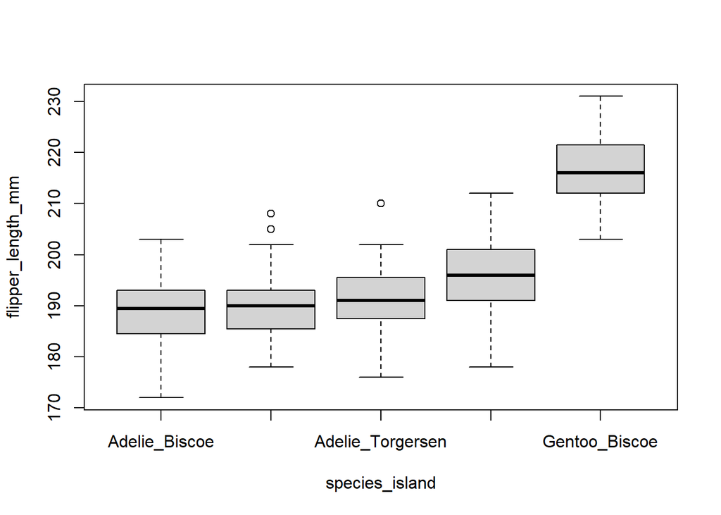

```r
#plotting flipper_length_mm by species and island using a boxplot and excluding NAs from the data
boxplot(flipper_length_mm ~ species_island, data = Peng_sp_isl)
```

```r
penguin_species_isl_extracredit <- penguins_no_na %>%
  mutate(species_island = cat(paste(penguins_no_na$species,penguins_no_na$island,sep="\n"))) #extra credit problem seeing what \n does to the dataset using paste and cat.
```

[output not shown]

[output cut: 279 more lines]

[output not shown]

3b. relationship between average flipper length and average body mass by species and island. I see a cluster of averages of smaller flipper sizes and body mass. There appears to be an outlier that has a huge flipper size and body mass average.

```r
peng_3b <- Peng_sp_isl %>% #creating a new vector for penguin data set to show avg flipper length and body mass
  group_by(species_island) %>% #grouping by species island column
  summarize(avg_flip=mean(flipper_length_mm),
            avg_body= mean(body_mass_g)) %>% #finding mean of flipper length and body mass
  ungroup() #ungrouping
```

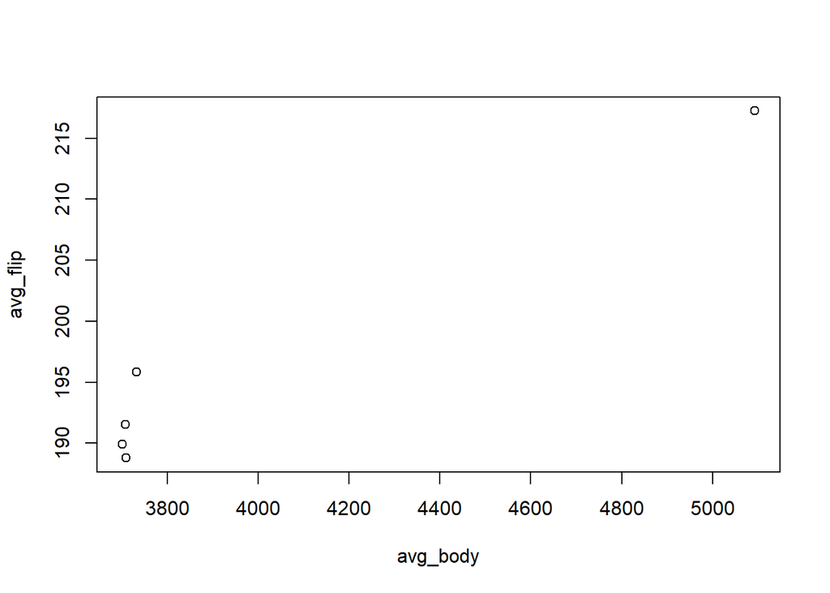

```r
  plot(avg_flip ~ avg_body, data = peng_3b) # plotting to see avg flipper length and avg body mass by species and island
```

3c. Plot with the whole dataset. The whole dataset shows a much clearer increase in body mass as flipper size increases. The plot could be clarified if the plot could distinguish between different penguin species. For example, if Adelie data was represented by squares in the plot, if Gentoos were represented by circles and if Chinstraps were represented by triangles the viewer could get a great sense of the different sizes of the different penguins in relation to one another.

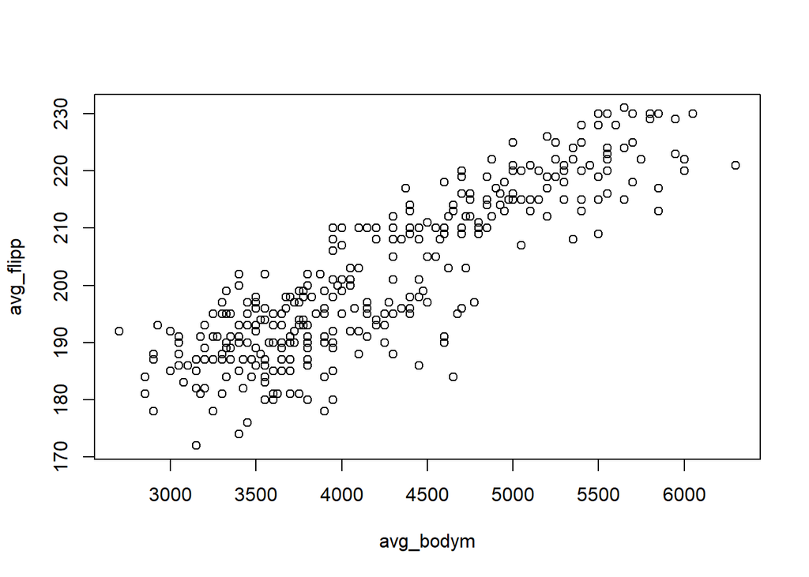

```r
whole_data_set <- penguins_no_na %>% #labeling new whole data set with no NAs
  group_by(flipper_length_mm, body_mass_g) %>%
      mutate(avg_flipp = mean(flipper_length_mm),
             avg_bodym = mean(body_mass_g)) %>% #adding average flipper and average body mass columns to the dataset that excludes NAs
  ungroup()

plot(avg_flipp ~ avg_bodym, data = whole_data_set) #plotting relationship between avg flipper length and average body mass from whole dataset
```

4a.Obtaining bill length for Gentoo penguins in Biscoe Island using the pull function.

```r
Gentoo_peng <- penguins_no_na %>%
        filter(species == "Gentoo") %>% #grabbing the Gentoo penguins in Biscoe island and putting it into an objet
        pull(bill_length_mm) #pulling out bill_length_mm from Gentoo penguins in Biscoe island

Gentoo_peng #viewing to see if I pulled the right data
```

```
##   [1] 46.1 50.0 48.7 50.0 47.6 46.5 45.4 46.7 43.3 46.8 40.9 49.0 45.5 48.4 45.8
##  [16] 49.3 42.0 49.2 46.2 48.7 50.2 45.1 46.5 46.3 42.9 46.1 47.8 48.2 50.0 47.3
##  [31] 42.8 45.1 59.6 49.1 48.4 42.6 44.4 44.0 48.7 42.7 49.6 45.3 49.6 50.5 43.6
##  [46] 45.5 50.5 44.9 45.2 46.6 48.5 45.1 50.1 46.5 45.0 43.8 45.5 43.2 50.4 45.3
##  [61] 46.2 45.7 54.3 45.8 49.8 49.5 43.5 50.7 47.7 46.4 48.2 46.5 46.4 48.6 47.5
##  [76] 51.1 45.2 45.2 49.1 52.5 47.4 50.0 44.9 50.8 43.4 51.3 47.5 52.1 47.5 52.2
##  [91] 45.5 49.5 44.5 50.8 49.4 46.9 48.4 51.1 48.5 55.9 47.2 49.1 46.8 41.7 53.4
## [106] 43.3 48.1 50.5 49.8 43.5 51.5 46.2 55.1 48.8 47.2 46.8 50.4 45.2 49.9
```

4b. Using replicate to calculate standard error of the mean 10 times. Standard error was found to be 0.2847372.

```r
library(purrr)


replicate(n = 10, sd(Gentoo_peng)/sqrt(length(Gentoo_peng))) #using replicate to get the standard error of the mean 10 times for bill_length
```

```
##  [1] 0.2847372 0.2847372 0.2847372 0.2847372 0.2847372 0.2847372 0.2847372
##  [8] 0.2847372 0.2847372 0.2847372
```

4c.Use map_df() to create a data frame with the mean and sd of different sample sizes using the first 5 through 100 values

```r
library(purrr)

new_df <- map_df(5:100, ~data.frame(n = .x,
                                    m = mean(Gentoo_peng[1:.x]),
                                    s = sd(Gentoo_peng[1:.x]))) #using map_df to create a dataframe using the first 5 through 100 values in the bill length of Gentoo penguins with the mean and sd of different sample sizes. .x helps us use the full dataframe
```